# ExpHunterSuite: Module Specific Report

SysBioLab

## **Used data in this analysis**

Specifically, in this experiment set, known experiment labels are:

- [C] GSM2858677
- [C] GSM2858679
- [C] GSM2858681
- [C] GSM2858684
- [C] GSM2858685
- [C] GSM2858687
- [C] GSM2858689
- [C] GSM2858691
- [C] GSM2858693
- [C] GSM2858695
- [C] GSM2858696
- [C] GSM2858698
- [C] GSM2858700
- [C] GSM2858703
- [C] GSM2858708
- [C] GSM2858709
- [C] GSM2858710
- [C] GSM2858714
- [C] GSM2858715
- [C] GSM2858717
- [C] GSM2858720
- [C] GSM2858721
- [C] GSM2858723
- [C] GSM2858724
- [C] GSM2858725
- [C] GSM2858733
- [C] GSM2858737
- [C] GSM2858738
- [C] GSM2858740
- [C] GSM2858741
- [C] GSM2858745
- [C] GSM2858747
- [C] GSM2858750
- [C] GSM2858751
- [C] GSM2858753
- [C] GSM2858755
- [C] GSM2858756
- [C] GSM2858758
- [C] GSM2858759
- [C] GSM2858763
- [C] GSM2858764
- [C] GSM2858768
- [C] GSM2858769
- [C] GSM2858771
- [C] GSM2858774
- [C] GSM2858776
- [C] GSM2858779
- [C] GSM2858781
- [C] GSM2858782
- [C] GSM2858783
- [C] GSM2858786
- [C] GSM2858787
- [T] GSM2858680
- [T] GSM2858683
- [T] GSM2858697
- [T] GSM2858702
- [T] GSM2858704
- [T] GSM2858706
- [T] GSM2858712
- [T] GSM2858719
- [T] GSM2858722
- [T] GSM2858728
- [T] GSM2858730
- [T] GSM2858731
- [T] GSM2858732
- [T] GSM2858734
- [T] GSM2858735
- [T] GSM2858736
- [T] GSM2858743
- [T] GSM2858744
- [T] GSM2858752
- [T] GSM2858754
- [T] GSM2858757
- [T] GSM2858762
- [T] GSM2858765
- [T] GSM2858770
- [T] GSM2858773
- [T] GSM2858775
- [T] GSM2858777
- [T] GSM2858778
- [T] GSM2858784
- [T] GSM2858785
- [T] GSM2858788
- [T] GSM2858790
- [T] GSM2858791
- [T] GSM2858793
- [T] GSM2858794
- [T] GSM2858795

## **General description**

This report contains all the functional information that was requested by the options when functional_Hunter.R was executed. The functional categories can be:

- KEGG pathways
- GO:
  - Biological Process
  - Molecular Function
  - Cellular Component
- Reactome pathways
- Custom nomenclature

All the functional categories are computed with CluterProfiler and GO caterogires are computed also with TopGo. Some sections will not show if there are not sinficative results. Each category is analysed using Over representation analysis (ORA) and Gene Set Analysis (GSEA). The ORA method takes a group of significative DEGs (only DEGs, upregulated DEGs or downregulated DEGs) and performs a hypergeometric test for each term of the selected functional category. In the case of the GSEA method, all the genes are sorted by their fold-change and the algorithm scan which genes with similar fold-change shares a term of the selected functional category. Statistics about input results obtained from DEGenes Expression Hunter are:

| Gene_tag | Genes |
| --- | --- |
| PREVALENT_DEG | 62 |

## **Profiles data**

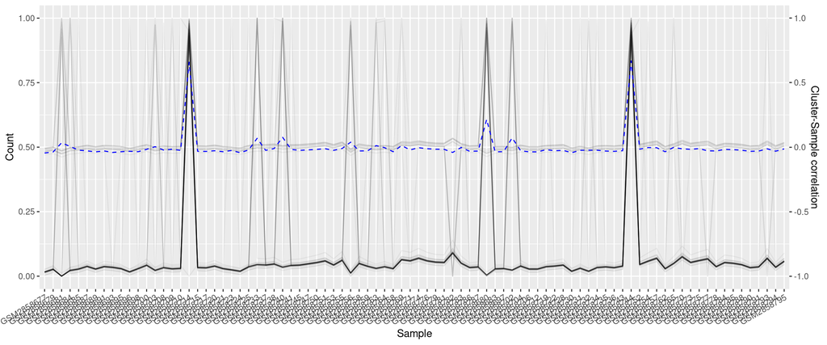

After apply a threshold of 0.05 over cluster correlation with Traits **any correlation have been tagged as significant**

## **MF - Over Representation Analysis**

The ORA method takes a group of significant genes and performs a Fisher’s exact test for each term of the selected functional category.

**Barplot**

The most highly signficant categories in ascending order, according to adjusted p-value. The x-axis represents the number of significant genes found within the functional category.

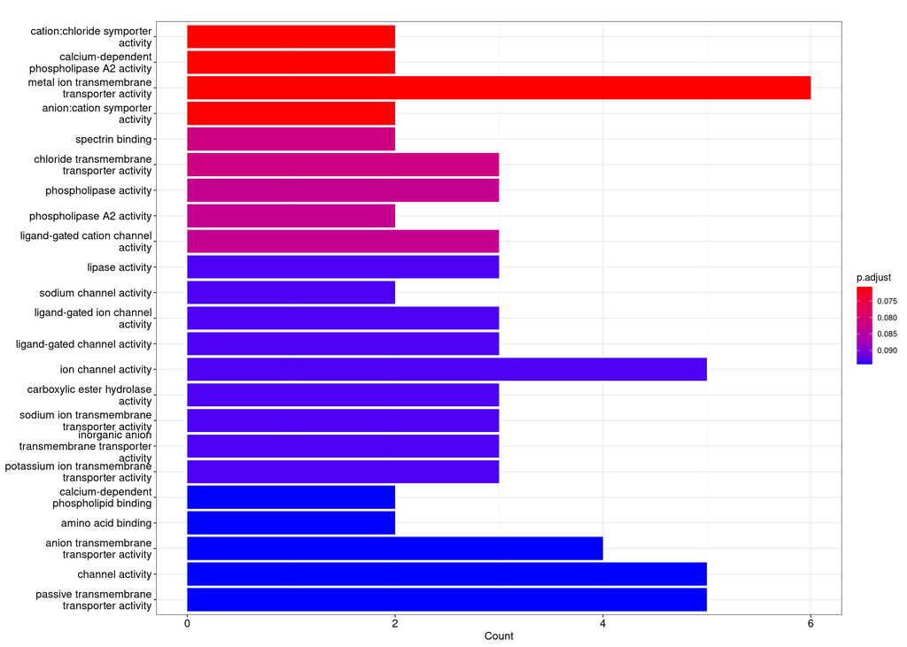

**Dotplot**

The most highly signficant categories in descending in categories of gene ratio, defined as the proportion of significant genes that are found in the functional category. The x-axis represents the gene ratio and the dot size the number of genes associated with the functional category.

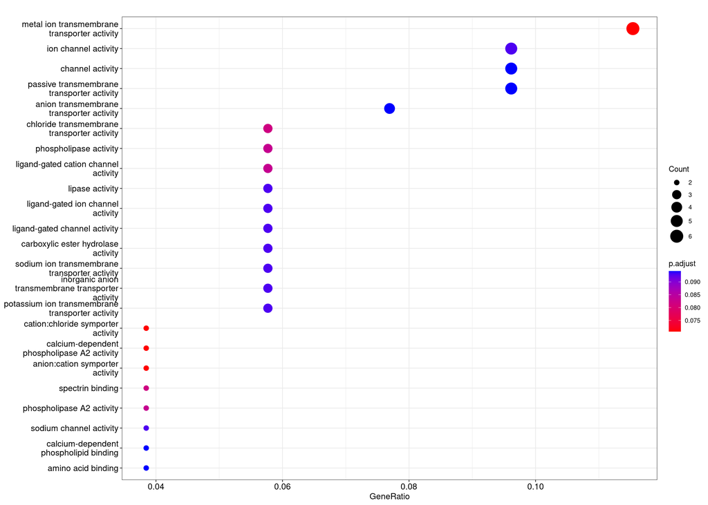

**Gene-Concept Network**

The network connects the top functional categories (brown nodes) to their associated genes (grey or colored nodes). The size of the functional category nodes shows the number of connected genes.

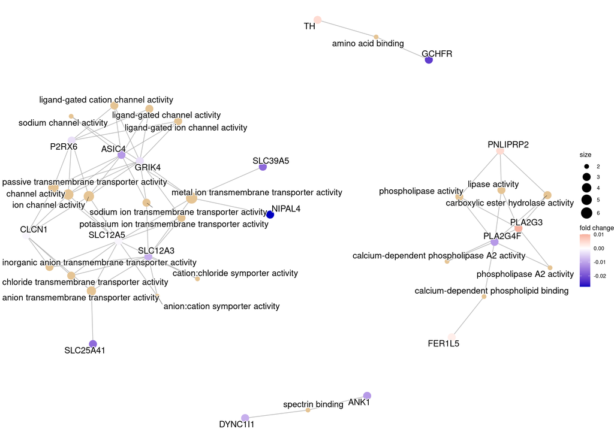

**Enrich Map plot**

The top functional categories (nodes), connected if they share genes. Edge thickness represents the number of shared genes. Nodes size represents the number of significant genes within the category.

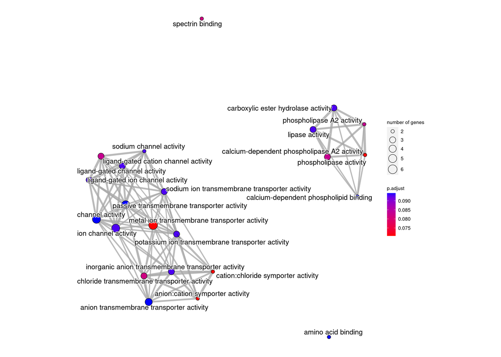

**Heatplot**

Significant genes (x-axis) and the functional categories in which they appear.

[figure not shown]

**Upsetplot**

Genes are clustered according to shared enriched categories. The y-axis shows the number of genes belonging to the different clusters (top) and categories to which they belong (bottom).

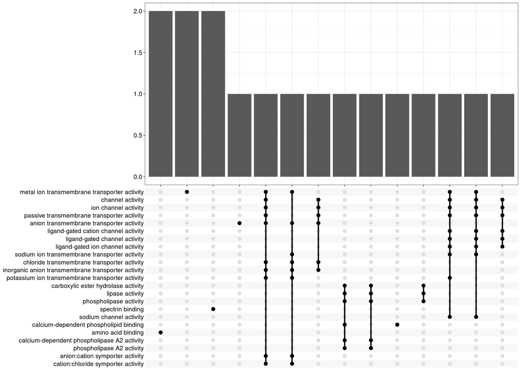

## **No enrichment found for BP**

## **No enrichment found for CC**